# Import required libraries & packages

```python
import warnings
import numpy as np  # linear algebra
import pandas as pd  # data processing
import seaborn as sns  # visualization
import pylab
import calendar
from scipy import stats
import missingno as msno
from datetime import datetime
import matplotlib.pyplot as plt
from matplotlib import style
import sklearn
from sklearn.ensemble import RandomForestRegressor,BaggingRegressor,GradientBoostingRegressor,AdaBoostRegressor
from sklearn.model_selection import train_test_split, cross_validate
from sklearn.model_selection import KFold
from sklearn.model_selection import GridSearchCV
from sklearn.metrics import accuracy_score,mean_squared_log_error,mean_squared_error, r2_score,mean_absolute_error # for regression
```

# Ignoring warning messages

```python
warnings.filterwarnings('always')
warnings.filterwarnings('ignore')
```

# Read raw data

```python
train_o = pd.read_csv("./train.csv")
test_o = pd.read_csv("./test.csv")
```

```python
train = train_o.copy()
test = test_o.copy()
```

```python
train
```

|  | datetime | season | holiday | workingday | weather | temp | atemp | humidity | windspeed | casual | registered | count |
| --- | --- | --- | --- | --- | --- | --- | --- | --- | --- | --- | --- | --- |
| 0 | 2011-01-01 00:00:00 | 1 | 0 | 0 | 1 | 9.84 | 14.395 | 81 | 0.0000 | 3 | 13 | 16 |
| 1 | 2011-01-01 01:00:00 | 1 | 0 | 0 | 1 | 9.02 | 13.635 | 80 | 0.0000 | 8 | 32 | 40 |
| 2 | 2011-01-01 02:00:00 | 1 | 0 | 0 | 1 | 9.02 | 13.635 | 80 | 0.0000 | 5 | 27 | 32 |
| 3 | 2011-01-01 03:00:00 | 1 | 0 | 0 | 1 | 9.84 | 14.395 | 75 | 0.0000 | 3 | 10 | 13 |
| 4 | 2011-01-01 04:00:00 | 1 | 0 | 0 | 1 | 9.84 | 14.395 | 75 | 0.0000 | 0 | 1 | 1 |
| ... | ... | ... | ... | ... | ... | ... | ... | ... | ... | ... | ... | ... |
| 10881 | 2012-12-19 19:00:00 | 4 | 0 | 1 | 1 | 15.58 | 19.695 | 50 | 26.0027 | 7 | 329 | 336 |
| 10882 | 2012-12-19 20:00:00 | 4 | 0 | 1 | 1 | 14.76 | 17.425 | 57 | 15.0013 | 10 | 231 | 241 |
| 10883 | 2012-12-19 21:00:00 | 4 | 0 | 1 | 1 | 13.94 | 15.910 | 61 | 15.0013 | 4 | 164 | 168 |
| 10884 | 2012-12-19 22:00:00 | 4 | 0 | 1 | 1 | 13.94 | 17.425 | 61 | 6.0032 | 12 | 117 | 129 |
| 10885 | 2012-12-19 23:00:00 | 4 | 0 | 1 | 1 | 13.12 | 16.665 | 66 | 8.9981 | 4 | 84 | 88 |

10886 rows × 12 columns

```python
test
```

|  | datetime | season | holiday | workingday | weather | temp | atemp | humidity | windspeed |
| --- | --- | --- | --- | --- | --- | --- | --- | --- | --- |
| 0 | 2011-01-20 00:00:00 | 1 | 0 | 1 | 1 | 10.66 | 11.365 | 56 | 26.0027 |
| 1 | 2011-01-20 01:00:00 | 1 | 0 | 1 | 1 | 10.66 | 13.635 | 56 | 0.0000 |
| 2 | 2011-01-20 02:00:00 | 1 | 0 | 1 | 1 | 10.66 | 13.635 | 56 | 0.0000 |
| 3 | 2011-01-20 03:00:00 | 1 | 0 | 1 | 1 | 10.66 | 12.880 | 56 | 11.0014 |
| 4 | 2011-01-20 04:00:00 | 1 | 0 | 1 | 1 | 10.66 | 12.880 | 56 | 11.0014 |
| ... | ... | ... | ... | ... | ... | ... | ... | ... | ... |
| 6488 | 2012-12-31 19:00:00 | 1 | 0 | 1 | 2 | 10.66 | 12.880 | 60 | 11.0014 |
| 6489 | 2012-12-31 20:00:00 | 1 | 0 | 1 | 2 | 10.66 | 12.880 | 60 | 11.0014 |
| 6490 | 2012-12-31 21:00:00 | 1 | 0 | 1 | 1 | 10.66 | 12.880 | 60 | 11.0014 |
| 6491 | 2012-12-31 22:00:00 | 1 | 0 | 1 | 1 | 10.66 | 13.635 | 56 | 8.9981 |
| 6492 | 2012-12-31 23:00:00 | 1 | 0 | 1 | 1 | 10.66 | 13.635 | 65 | 8.9981 |

6493 rows × 9 columns

# EDA

## Checking the data formats of each column (attributes)

### Checking the unique columns

```python
train.columns.unique()
```

```
Index(['datetime', 'season', 'holiday', 'workingday', 'weather', 'temp',
       'atemp', 'humidity', 'windspeed', 'casual', 'registered', 'count'],
      dtype='object')
```

### Check whether there exists null values in the data

```python
print(train.isnull().sum().sort_values(ascending = False))
print("*"*50)
print(test.isnull().sum().sort_values(ascending = False))
```

```
datetime      0
season        0
holiday       0
workingday    0
weather       0
temp          0
atemp         0
humidity      0
windspeed     0
casual        0
registered    0
count         0
dtype: int64
datetime      0
season        0
holiday       0
workingday    0
weather       0
temp          0
atemp         0
humidity      0
windspeed     0
dtype: int64
```

We can see there are no null values.

### Checking data types

```python
train.info()
test.info()
```

```
<class 'pandas.core.frame.DataFrame'>
RangeIndex: 10886 entries, 0 to 10885
Data columns (total 12 columns):
 #   Column      Non-Null Count  Dtype
---  ------      --------------  -----
 0   datetime    10886 non-null  object
 1   season      10886 non-null  int64
 2   holiday     10886 non-null  int64
 3   workingday  10886 non-null  int64
 4   weather     10886 non-null  int64
 5   temp        10886 non-null  float64
 6   atemp       10886 non-null  float64
 7   humidity    10886 non-null  int64
 8   windspeed   10886 non-null  float64
 9   casual      10886 non-null  int64
 10  registered  10886 non-null  int64
 11  count       10886 non-null  int64
dtypes: float64(3), int64(8), object(1)
memory usage: 1020.7+ KB
<class 'pandas.core.frame.DataFrame'>
RangeIndex: 6493 entries, 0 to 6492
Data columns (total 9 columns):
 #   Column      Non-Null Count  Dtype
---  ------      --------------  -----
 0   datetime    6493 non-null   object
 1   season      6493 non-null   int64
 2   holiday     6493 non-null   int64
 3   workingday  6493 non-null   int64
 4   weather     6493 non-null   int64
 5   temp        6493 non-null   float64
 6   atemp       6493 non-null   float64
 7   humidity    6493 non-null   int64
 8   windspeed   6493 non-null   float64
dtypes: float64(3), int64(5), object(1)
memory usage: 456.7+ KB
```

Here we got a really clean and tidy dataset.

## Analysis of the data set

### For discrete columns:

We focus on each column, to figure out the insights through the charts

### Season

```python
train.season.value_counts() #the season column
```

```
4    2734
2    2733
3    2733
1    2686
Name: season, dtype: int64
```

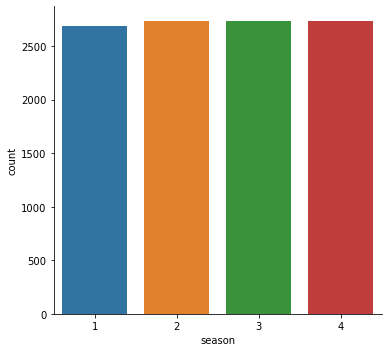

```python
sns.factorplot(x='season',data=train,kind='count',size=5,aspect=1.10) #plotting it against the prediction variable
```

### Holiday

```python
train.holiday.value_counts()
```

```
0    10575
1      311
Name: holiday, dtype: int64
```

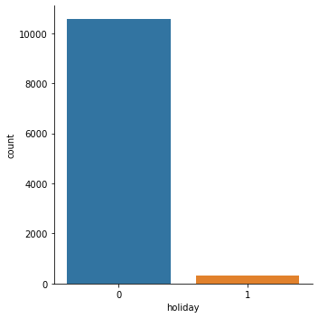

```python
sns.factorplot(x='holiday',data=train,kind='count',size=5,aspect=1) # majority of data is for non holiday days.
```

### Working day

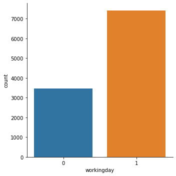

```python
train.workingday.value_counts()
sns.factorplot(x='workingday',data=train,kind='count',size=5,aspect=1) # majority of data is for working days.
```

We see maximum people rent bikes on a working day as expected.

### Weather

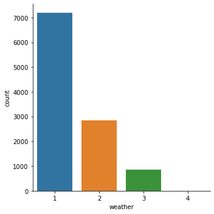

```python
train.weather.value_counts()
sns.factorplot(x='weather',data=train,kind='count',size=5,aspect=1)
```

We see maximum people rent bikes when the weather is clear (value 1).

There is only one data point for the value 4 in weather column. We can delete this feature value later.

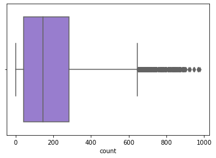

```python
#Boxplot for count

import matplotlib.pyplot as plt
sns.boxplot(x = 'count', data = train, color = 'mediumpurple')
plt.show()
```

This plot tells us a lot about our target variable.

- Our target variable, count is not normally distributed.
- Our target variable is right-skewed.
- There are multiple outliers in the variable.

### Stochastic number summary for the data set

```python
train.describe()
```

|  | season | holiday | workingday | weather | temp | atemp | humidity | windspeed | casual | registered | count |
| --- | --- | --- | --- | --- | --- | --- | --- | --- | --- | --- | --- |
| count | 10886.000000 | 10886.000000 | 10886.000000 | 10886.000000 | 10886.00000 | 10886.000000 | 10886.000000 | 10886.000000 | 10886.000000 | 10886.000000 | 10886.000000 |
| mean | 2.506614 | 0.028569 | 0.680875 | 1.418427 | 20.23086 | 23.655084 | 61.886460 | 12.799395 | 36.021955 | 155.552177 | 191.574132 |
| std | 1.116174 | 0.166599 | 0.466159 | 0.633839 | 7.79159 | 8.474601 | 19.245033 | 8.164537 | 49.960477 | 151.039033 | 181.144454 |
| min | 1.000000 | 0.000000 | 0.000000 | 1.000000 | 0.82000 | 0.760000 | 0.000000 | 0.000000 | 0.000000 | 0.000000 | 1.000000 |
| 25% | 2.000000 | 0.000000 | 0.000000 | 1.000000 | 13.94000 | 16.665000 | 47.000000 | 7.001500 | 4.000000 | 36.000000 | 42.000000 |
| 50% | 3.000000 | 0.000000 | 1.000000 | 1.000000 | 20.50000 | 24.240000 | 62.000000 | 12.998000 | 17.000000 | 118.000000 | 145.000000 |
| 75% | 4.000000 | 0.000000 | 1.000000 | 2.000000 | 26.24000 | 31.060000 | 77.000000 | 16.997900 | 49.000000 | 222.000000 | 284.000000 |
| max | 4.000000 | 1.000000 | 1.000000 | 4.000000 | 41.00000 | 45.455000 | 100.000000 | 56.996900 | 367.000000 | 886.000000 | 977.000000 |

### Distribution for all continuous columns

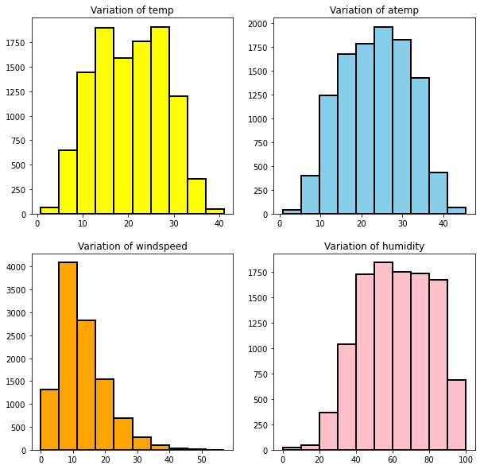

```python
# histogram of all continuous variables

train.temp.unique()
fig,axes=plt.subplots(2,2)
axes[0,0].hist(x="temp",data=train,edgecolor="black",linewidth=2,color='yellow')
axes[0,0].set_title("Variation of temp")
axes[0,1].hist(x="atemp",data=train,edgecolor="black",linewidth=2,color='skyblue')
axes[0,1].set_title("Variation of atemp")
axes[1,0].hist(x="windspeed",data=train,edgecolor="black",linewidth=2,color='orange')
axes[1,0].set_title("Variation of windspeed")
axes[1,1].hist(x="humidity",data=train,edgecolor="black",linewidth=2,color='pink')
axes[1,1].set_title("Variation of humidity")
fig.set_size_inches(10,10)
```

### Interrelationship for all features

For all the columns with continuous & discrete data types, we can calculate and display their interrelationship using heatmap.

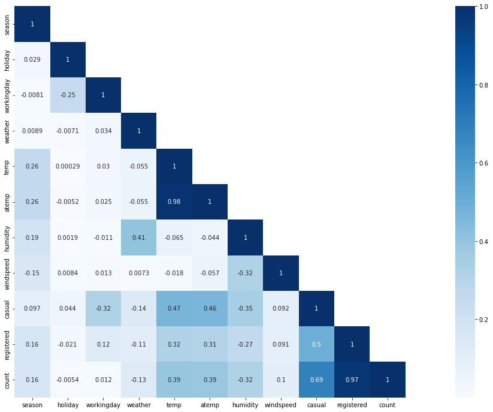

```python
#corelation matrix.
cor_mat= train[:].corr()
mask = np.array(cor_mat)
mask[np.tril_indices_from(mask)] = False
fig=plt.gcf()
fig.set_size_inches(30,12)
sns.heatmap(data=np.abs(cor_mat),mask=mask,square=True,annot=cor_mat,cbar=True,cmap='Blues')
```

### Line plot for all continuous columns

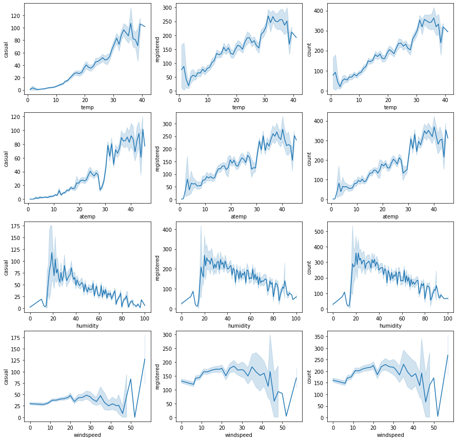

```python
y = ['casual','registered','count']
list_continuous = ['temp','atemp','humidity','windspeed']
n=3
s= 15
f,axes = plt.subplots(4,3,figsize = (s,s))
counter = 0
for i in list_continuous:
    for j in y:
        sns.lineplot(x = i , y = j , data  = train, ax = axes[counter//n][counter%n])
        counter+=1
```

We can infer from the correlaton matrix and lineplots that windspeed has no significant correlation with the casual,registered or count which we wish to predict. So we can consider removing that column later.

Now, we can perform feature engineering. We can add some important variables, & drop the unimportant ones.

### Split the timestamp in datatime column to hour, day, month and year

```python
train["hour"] = [t.hour for t in pd.DatetimeIndex(train.datetime)]
train["day"] = [t.dayofweek for t in pd.DatetimeIndex(train.datetime)]
train["month"] = [t.month for t in pd.DatetimeIndex(train.datetime)]
train['year'] = [t.year for t in pd.DatetimeIndex(train.datetime)]
train['year'] = train['year'].map({2011:0, 2012:1})
train.head()
```

|  | datetime | season | holiday | workingday | weather | temp | atemp | humidity | windspeed | casual | registered | count | hour | day | month | year |
| --- | --- | --- | --- | --- | --- | --- | --- | --- | --- | --- | --- | --- | --- | --- | --- | --- |
| 0 | 2011-01-01 00:00:00 | 1 | 0 | 0 | 1 | 9.84 | 14.395 | 81 | 0.0 | 3 | 13 | 16 | 0 | 5 | 1 | 0 |
| 1 | 2011-01-01 01:00:00 | 1 | 0 | 0 | 1 | 9.02 | 13.635 | 80 | 0.0 | 8 | 32 | 40 | 1 | 5 | 1 | 0 |
| 2 | 2011-01-01 02:00:00 | 1 | 0 | 0 | 1 | 9.02 | 13.635 | 80 | 0.0 | 5 | 27 | 32 | 2 | 5 | 1 | 0 |
| 3 | 2011-01-01 03:00:00 | 1 | 0 | 0 | 1 | 9.84 | 14.395 | 75 | 0.0 | 3 | 10 | 13 | 3 | 5 | 1 | 0 |
| 4 | 2011-01-01 04:00:00 | 1 | 0 | 0 | 1 | 9.84 | 14.395 | 75 | 0.0 | 0 | 1 | 1 | 4 | 5 | 1 | 0 |

### Split season data into 4 binary features

```python
season=pd.get_dummies(train['season'],prefix='season')
train=pd.concat([train,season],axis=1)
train.head()
```

|  | datetime | season | holiday | workingday | weather | temp | atemp | humidity | windspeed | casual | registered | count | hour | day | month | year | season_1 | season_2 | season_3 | season_4 |
| --- | --- | --- | --- | --- | --- | --- | --- | --- | --- | --- | --- | --- | --- | --- | --- | --- | --- | --- | --- | --- |
| 0 | 2011-01-01 00:00:00 | 1 | 0 | 0 | 1 | 9.84 | 14.395 | 81 | 0.0 | 3 | 13 | 16 | 0 | 5 | 1 | 0 | 1 | 0 | 0 | 0 |
| 1 | 2011-01-01 01:00:00 | 1 | 0 | 0 | 1 | 9.02 | 13.635 | 80 | 0.0 | 8 | 32 | 40 | 1 | 5 | 1 | 0 | 1 | 0 | 0 | 0 |
| 2 | 2011-01-01 02:00:00 | 1 | 0 | 0 | 1 | 9.02 | 13.635 | 80 | 0.0 | 5 | 27 | 32 | 2 | 5 | 1 | 0 | 1 | 0 | 0 | 0 |
| 3 | 2011-01-01 03:00:00 | 1 | 0 | 0 | 1 | 9.84 | 14.395 | 75 | 0.0 | 3 | 10 | 13 | 3 | 5 | 1 | 0 | 1 | 0 | 0 | 0 |
| 4 | 2011-01-01 04:00:00 | 1 | 0 | 0 | 1 | 9.84 | 14.395 | 75 | 0.0 | 0 | 1 | 1 | 4 | 5 | 1 | 0 | 1 | 0 | 0 | 0 |

### Change the sub_season column names

```python
name_change = {'season_1' : 'spring',
               'season_2' : 'summer',
               'season_3' : 'fall',
               'season_4' : 'winter'}
train = train.rename(columns = name_change)
```

```python
train.drop(['season'],inplace=True,axis=1)
train.head()
train.drop('datetime',axis=1,inplace=True)
train.head()
```

|  | holiday | workingday | weather | temp | atemp | humidity | windspeed | casual | registered | count | hour | day | month | year | spring | summer | fall | winter |
| --- | --- | --- | --- | --- | --- | --- | --- | --- | --- | --- | --- | --- | --- | --- | --- | --- | --- | --- |
| 0 | 0 | 0 | 1 | 9.84 | 14.395 | 81 | 0.0 | 3 | 13 | 16 | 0 | 5 | 1 | 0 | 1 | 0 | 0 | 0 |
| 1 | 0 | 0 | 1 | 9.02 | 13.635 | 80 | 0.0 | 8 | 32 | 40 | 1 | 5 | 1 | 0 | 1 | 0 | 0 | 0 |
| 2 | 0 | 0 | 1 | 9.02 | 13.635 | 80 | 0.0 | 5 | 27 | 32 | 2 | 5 | 1 | 0 | 1 | 0 | 0 | 0 |
| 3 | 0 | 0 | 1 | 9.84 | 14.395 | 75 | 0.0 | 3 | 10 | 13 | 3 | 5 | 1 | 0 | 1 | 0 | 0 | 0 |
| 4 | 0 | 0 | 1 | 9.84 | 14.395 | 75 | 0.0 | 0 | 1 | 1 | 4 | 5 | 1 | 0 | 1 | 0 | 0 | 0 |

We set train_m as modified train dataset.

```python
train_m=train[~train['weather'].isin([4])]
```

```python
train_m=train_m[~train_m['holiday'].isin([1])]
```

```python
trainm_wo_outlier = train_m[np.abs(train_m["count"]-train_m["count"].mean())<=(3*train_m["count"].std())]
```

```python
trainm_wo_outlier["count"] = np.log(trainm_wo_outlier["count"])
```

```python
trainm_wo_outlier.drop(["casual", "registered", "year"],axis=1,inplace = True)
```

```python
trainm_wo_outlier
```

|  | holiday | workingday | weather | temp | atemp | humidity | windspeed | count | hour | day | month | spring | summer | fall | winter |
| --- | --- | --- | --- | --- | --- | --- | --- | --- | --- | --- | --- | --- | --- | --- | --- |
| 0 | 0 | 0 | 1 | 9.84 | 14.395 | 81 | 0.0000 | 2.772589 | 0 | 5 | 1 | 1 | 0 | 0 | 0 |
| 1 | 0 | 0 | 1 | 9.02 | 13.635 | 80 | 0.0000 | 3.688879 | 1 | 5 | 1 | 1 | 0 | 0 | 0 |
| 2 | 0 | 0 | 1 | 9.02 | 13.635 | 80 | 0.0000 | 3.465736 | 2 | 5 | 1 | 1 | 0 | 0 | 0 |
| 3 | 0 | 0 | 1 | 9.84 | 14.395 | 75 | 0.0000 | 2.564949 | 3 | 5 | 1 | 1 | 0 | 0 | 0 |
| 4 | 0 | 0 | 1 | 9.84 | 14.395 | 75 | 0.0000 | 0.000000 | 4 | 5 | 1 | 1 | 0 | 0 | 0 |
| ... | ... | ... | ... | ... | ... | ... | ... | ... | ... | ... | ... | ... | ... | ... | ... |
| 10881 | 0 | 1 | 1 | 15.58 | 19.695 | 50 | 26.0027 | 5.817111 | 19 | 2 | 12 | 0 | 0 | 0 | 1 |
| 10882 | 0 | 1 | 1 | 14.76 | 17.425 | 57 | 15.0013 | 5.484797 | 20 | 2 | 12 | 0 | 0 | 0 | 1 |
| 10883 | 0 | 1 | 1 | 13.94 | 15.910 | 61 | 15.0013 | 5.123964 | 21 | 2 | 12 | 0 | 0 | 0 | 1 |
| 10884 | 0 | 1 | 1 | 13.94 | 17.425 | 61 | 6.0032 | 4.859812 | 22 | 2 | 12 | 0 | 0 | 0 | 1 |
| 10885 | 0 | 1 | 1 | 13.12 | 16.665 | 66 | 8.9981 | 4.477337 | 23 | 2 | 12 | 0 | 0 | 0 | 1 |

10427 rows × 15 columns

### New inter-relationships for all features

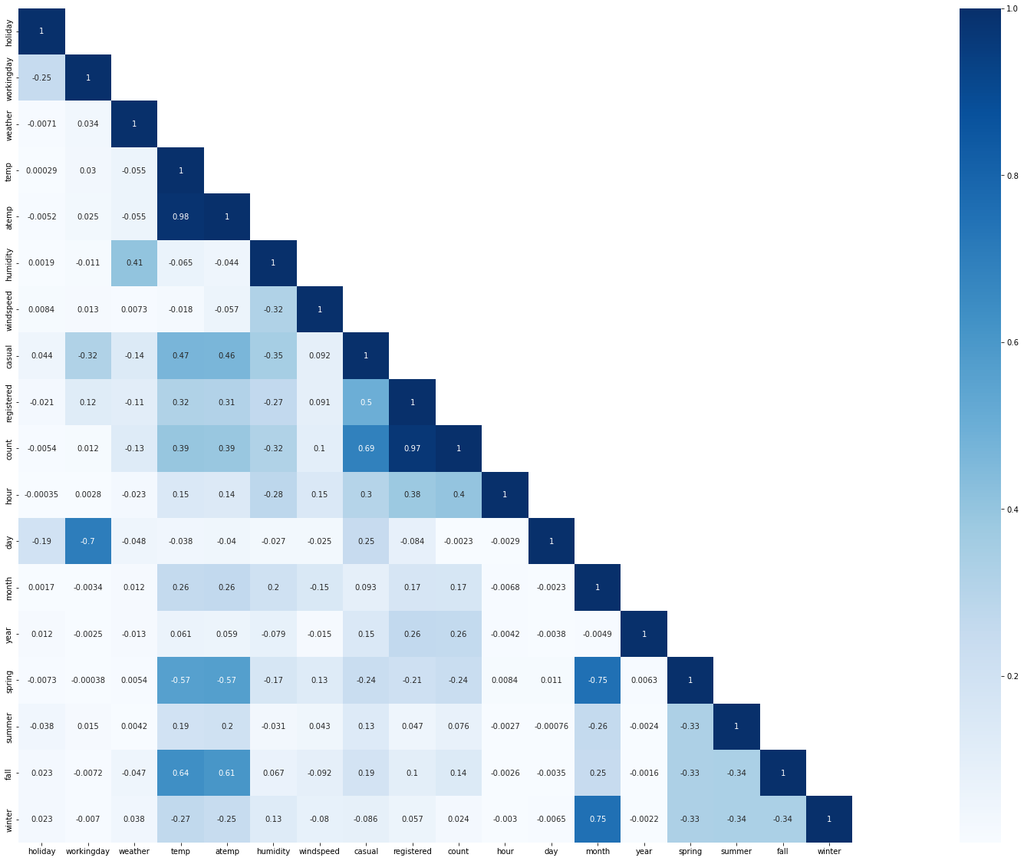

```python
cor_mat= train[:].corr()
mask = np.array(cor_mat)
mask[np.tril_indices_from(mask)] = False
fig=plt.gcf()
fig.set_size_inches(50,20)
sns.heatmap(data=np.abs(cor_mat),mask=mask,square=True,annot=cor_mat,cbar=True,cmap='Blues')
```

### Count variable's relation to the newly added features :

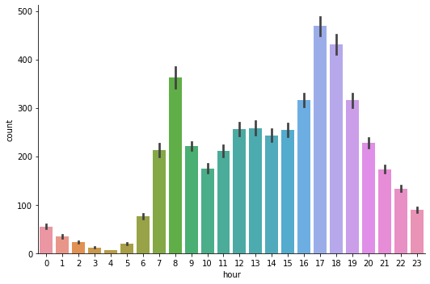

```python
sns.factorplot(x="hour",y="count",data=train,kind='bar',size=5,aspect=1.5)
```

##### we see that the highest demand is during hours from say 7-9 and then from 16-19. This is because in most of the metropolitan cities, these are the peak office times and so, more people would be renting bikes.

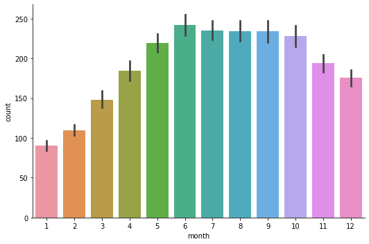

```python
sns.factorplot(x="month",y="count",data=train,kind='bar',size=5,aspect=1.5)
```

##### It is understandable that month affects the season (like spring, summer etc). Season affects the weather (rainzy, hazy, etc) & these conditions affect the renting of bikes.

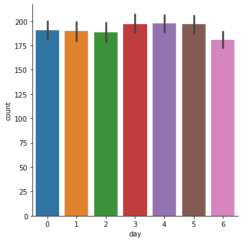

```python
sns.factorplot(x="day",y='count',kind='bar',data=train,size=5,aspect=1)
```

```python
new_df=train.copy()
new_df.temp.describe()
```

```
count    10886.00000
mean        20.23086
std          7.79159
min          0.82000
25%         13.94000
50%         20.50000
75%         26.24000
max         41.00000
Name: temp, dtype: float64
```

We use pd.cut executing data discretation and segmetation

```python
list_bin = [0, 5, 10, 15, 20, 25, 30, 35, 100]
list_label = ['0-5', '5-10', '10-15', '15-20', '20-25', '25-30', '30-35', '>35']
new_df['temp_range'] = pd.cut(new_df['temp'], bins = list_bin, labels = list_label)
```

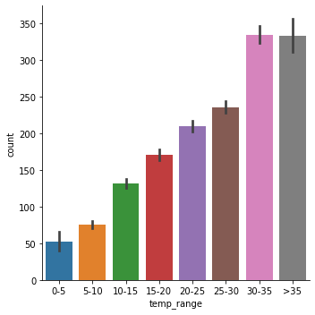

```python
sns.factorplot(x="temp_range",y="count",data=new_df,kind='bar')
```

We can see sharing bike requirement is increased as the temperature escalates.

### For operations, we use the copy of our original data

```python
train_s = train_o.copy()
```

```python
train_s
```

|  | datetime | season | holiday | workingday | weather | temp | atemp | humidity | windspeed | casual | registered | count |
| --- | --- | --- | --- | --- | --- | --- | --- | --- | --- | --- | --- | --- |
| 0 | 2011-01-01 00:00:00 | 1 | 0 | 0 | 1 | 9.84 | 14.395 | 81 | 0.0000 | 3 | 13 | 16 |
| 1 | 2011-01-01 01:00:00 | 1 | 0 | 0 | 1 | 9.02 | 13.635 | 80 | 0.0000 | 8 | 32 | 40 |
| 2 | 2011-01-01 02:00:00 | 1 | 0 | 0 | 1 | 9.02 | 13.635 | 80 | 0.0000 | 5 | 27 | 32 |
| 3 | 2011-01-01 03:00:00 | 1 | 0 | 0 | 1 | 9.84 | 14.395 | 75 | 0.0000 | 3 | 10 | 13 |
| 4 | 2011-01-01 04:00:00 | 1 | 0 | 0 | 1 | 9.84 | 14.395 | 75 | 0.0000 | 0 | 1 | 1 |
| ... | ... | ... | ... | ... | ... | ... | ... | ... | ... | ... | ... | ... |
| 10881 | 2012-12-19 19:00:00 | 4 | 0 | 1 | 1 | 15.58 | 19.695 | 50 | 26.0027 | 7 | 329 | 336 |
| 10882 | 2012-12-19 20:00:00 | 4 | 0 | 1 | 1 | 14.76 | 17.425 | 57 | 15.0013 | 10 | 231 | 241 |
| 10883 | 2012-12-19 21:00:00 | 4 | 0 | 1 | 1 | 13.94 | 15.910 | 61 | 15.0013 | 4 | 164 | 168 |
| 10884 | 2012-12-19 22:00:00 | 4 | 0 | 1 | 1 | 13.94 | 17.425 | 61 | 6.0032 | 12 | 117 | 129 |
| 10885 | 2012-12-19 23:00:00 | 4 | 0 | 1 | 1 | 13.12 | 16.665 | 66 | 8.9981 | 4 | 84 | 88 |

10886 rows × 12 columns

## Feature engineering

As we see from the above results, the columns "season","holiday","workingday" and "weather" should be of "categorical" data type.But the current data type is "int" for those columns. Let us transform the dataset in the following ways so that we can get started up with our EDA.

- Create new columns "date,"hour","weekDay","month" from "datetime" column.
- Coerce the datatype of "season","holiday","workingday" and weather to category.
- Drop the datetime column as we already extracted useful features from it.

### Spilt datatime column & coerce to category type

Performing additional analysis to understand the features -

```python
train_s["date"] = train_s.datetime.apply(lambda x : x.split()[0])
train_s["hour"] = train_s.datetime.apply(lambda x : x.split()[1].split(":")[0])
train_s["weekday"] = train_s.date.apply(lambda dateString : calendar.day_name[datetime.strptime(dateString,"%Y-%m-%d").weekday()])
train_s["month"] = train_s.date.apply(lambda dateString : calendar.month_name[datetime.strptime(dateString,"%Y-%m-%d").month])
train_s["season"] = train_s.season.map({1: "Spring", 2 : "Summer", 3 : "Fall", 4 :"Winter" })
train_s  = train_s.drop(["datetime"],axis=1)
```

```python
categoryVariableList = ["hour","weekday","month","season","holiday","workingday"]
for var in categoryVariableList:
    train_s[var] = train_s[var].astype("category")
```

```python
train_s
```

|  | season | holiday | workingday | weather | temp | atemp | humidity | windspeed | casual | registered | count | date | hour | weekday | month |
| --- | --- | --- | --- | --- | --- | --- | --- | --- | --- | --- | --- | --- | --- | --- | --- |
| 0 | Spring | 0 | 0 | 1 | 9.84 | 14.395 | 81 | 0.0000 | 3 | 13 | 16 | 2011-01-01 | 00 | Saturday | January |
| 1 | Spring | 0 | 0 | 1 | 9.02 | 13.635 | 80 | 0.0000 | 8 | 32 | 40 | 2011-01-01 | 01 | Saturday | January |
| 2 | Spring | 0 | 0 | 1 | 9.02 | 13.635 | 80 | 0.0000 | 5 | 27 | 32 | 2011-01-01 | 02 | Saturday | January |
| 3 | Spring | 0 | 0 | 1 | 9.84 | 14.395 | 75 | 0.0000 | 3 | 10 | 13 | 2011-01-01 | 03 | Saturday | January |
| 4 | Spring | 0 | 0 | 1 | 9.84 | 14.395 | 75 | 0.0000 | 0 | 1 | 1 | 2011-01-01 | 04 | Saturday | January |
| ... | ... | ... | ... | ... | ... | ... | ... | ... | ... | ... | ... | ... | ... | ... | ... |
| 10881 | Winter | 0 | 1 | 1 | 15.58 | 19.695 | 50 | 26.0027 | 7 | 329 | 336 | 2012-12-19 | 19 | Wednesday | December |
| 10882 | Winter | 0 | 1 | 1 | 14.76 | 17.425 | 57 | 15.0013 | 10 | 231 | 241 | 2012-12-19 | 20 | Wednesday | December |
| 10883 | Winter | 0 | 1 | 1 | 13.94 | 15.910 | 61 | 15.0013 | 4 | 164 | 168 | 2012-12-19 | 21 | Wednesday | December |
| 10884 | Winter | 0 | 1 | 1 | 13.94 | 17.425 | 61 | 6.0032 | 12 | 117 | 129 | 2012-12-19 | 22 | Wednesday | December |
| 10885 | Winter | 0 | 1 | 1 | 13.12 | 16.665 | 66 | 8.9981 | 4 | 84 | 88 | 2012-12-19 | 23 | Wednesday | December |

10886 rows × 15 columns

```python
train_s_df = pd.DataFrame(train_s.dtypes.value_counts()).reset_index().rename(columns={"index":"VariableType",0:"count"})
train_s_df
```

|  | VariableType | count |
| --- | --- | --- |
| 0 | int64 | 5 |
| 1 | float64 | 3 |
| 2 | category | 2 |
| 3 | category | 1 |
| 4 | object | 1 |
| 5 | category | 1 |
| 6 | category | 1 |
| 7 | category | 1 |

## Outlier Analysis

At first look, "count" variable contains lot of outlier data points which skews the distribution towards right (as there are more data points beyond Outer Quartile Limit).But in addition to that, following inferences can also been made from the simple boxplots given below.

[output not shown]

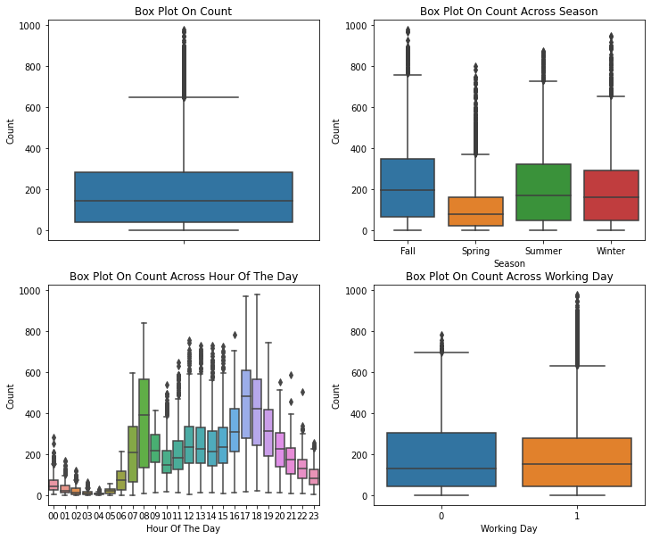

```python
fig, axes = plt.subplots(nrows=2,ncols=2)
fig.set_size_inches(12, 10)
sns.boxplot(data=train_s,y="count",orient="v",ax=axes[0][0])
sns.boxplot(data=train_s,y="count",x="season",orient="v",ax=axes[0][1])
sns.boxplot(data=train_s,y="count",x="hour",orient="v",ax=axes[1][0])
sns.boxplot(data=train_s,y="count",x="workingday",orient="v",ax=axes[1][1])

axes[0][0].set(ylabel='Count',title="Box Plot On Count")
axes[0][1].set(xlabel='Season', ylabel='Count',title="Box Plot On Count Across Season")
axes[1][0].set(xlabel='Hour Of The Day', ylabel='Count',title="Box Plot On Count Across Hour Of The Day")
axes[1][1].set(xlabel='Working Day', ylabel='Count',title="Box Plot On Count Across Working Day")
```

We remove all the outliers by setting a threshold of no larger than 3 times the std. deviation

```python
trains_wo_outlier = train_s[np.abs(train_s["count"]-train_s["count"].mean())<=(3*train_s["count"].std())]
```

```python
print ("Shape Of The Before Ouliers: ",train_s.shape)
print ("Shape Of The After Ouliers: ",trains_wo_outlier.shape)
```

```
Shape Of The Before Ouliers:  (10886, 15)
Shape Of The After Ouliers:  (10739, 15)
```

## Correlation Analysis

One common to understand how a dependent variable is influenced by features (numerical) is to find a correlation matrix between them. Lets plot a correlation plot between "count" and ["temp","atemp","humidity","windspeed"].

- temp and humidity features has got positive and negative correlation with count respectively. Although the correlation between them are not very prominent still the count variable has got little dependency on "temp" and "humidity".
- windspeed is not gonna be really useful numerical feature and it is visible from it correlation value with "count"
- "atemp" is variable is not taken into since "atemp" and "temp" has got strong correlation with each other. During model building any one of the variable has to be dropped since they will exhibit multicollinearity in the data.
- "Casual" and "Registered" are also not taken into account since they are leakage variables in nature and need to dropped during model building.

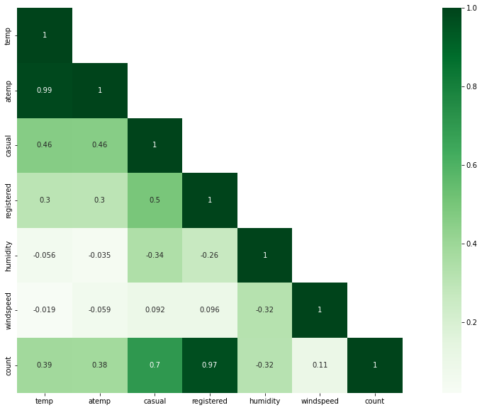

```python
corrMatt = trains_wo_outlier[["temp","atemp","casual","registered","humidity","windspeed","count"]].corr()
mask = np.array(corrMatt)
mask[np.tril_indices_from(mask)] = False
fig,ax= plt.subplots()
fig.set_size_inches(20,10)
sns.heatmap(data=np.abs(corrMatt),mask=mask,square=True,annot=corrMatt,cbar=True,cmap='Greens')
```

Regression plot in seaborn is one useful way to depict the relationship between two features. Here we consider "count" vs "temp", "humidity", "windspeed".

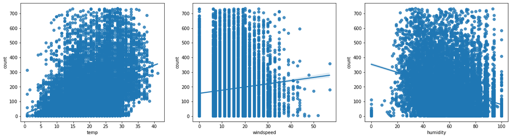

```python
fig,(ax1,ax2,ax3) = plt.subplots(ncols=3)
fig.set_size_inches(20, 5)
sns.regplot(x="temp", y="count", data=trains_wo_outlier,ax=ax1)
sns.regplot(x="windspeed", y="count", data=trains_wo_outlier,ax=ax2)
sns.regplot(x="humidity", y="count", data=trains_wo_outlier,ax=ax3)
```

### Visualizing Distribution Of Data

As it is visible from the below figures that "count" variable is skewed towards right. It is desirable to have Normal distribution as most of the machine learning techniques require dependent variable to be Normal. One possible solution is to take log transformation on "count" variable after removing outlier data points. After the transformation the data looks lot better but still not ideally following normal distribution.

```
((array([-3.82819677, -3.60401975, -3.48099008, ...,  3.48099008,
          3.60401975,  3.82819677]),
  array([0.69314718, 0.69314718, 0.69314718, ..., 6.5971457 , 6.59850903,
         6.5998705 ])),
 (1.3486990121229774, 4.562423868087808, 0.9581176780909615))
```

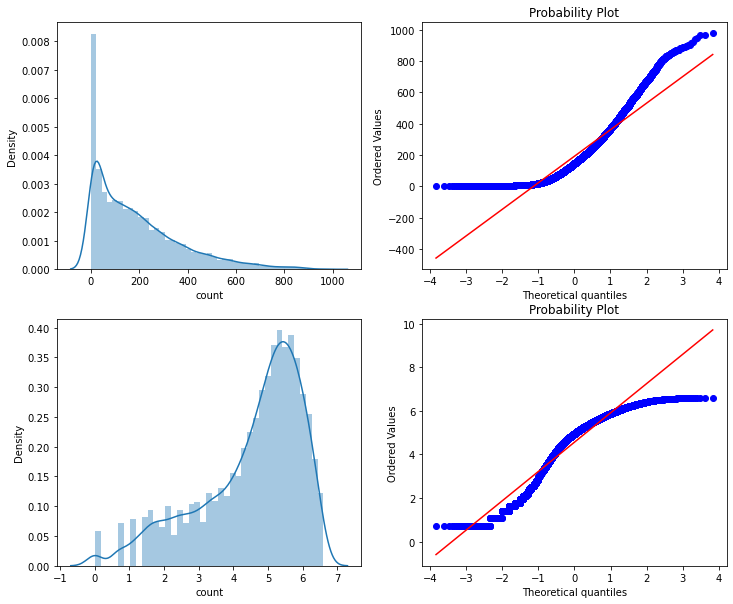

```python
fig,axes = plt.subplots(ncols=2,nrows=2)
fig.set_size_inches(12, 10)
sns.distplot(train_s["count"],ax=axes[0][0])
stats.probplot(train_s["count"], dist='norm', fit=True, plot=axes[0][1])
sns.distplot(np.log(trains_wo_outlier["count"]),ax=axes[1][0])
stats.probplot(np.log1p(trains_wo_outlier["count"]), dist='norm', fit=True, plot=axes[1][1])
```

### Visualizing Count Vs (Month,Season,Hour,Weekday,Usertype)

- It is quiet obvious that people tend to rent bike during summer season since it is really conducive to ride bike at that season.Therefore June, July and August has got relatively higher demand for bicycle.
- On weekdays more people tend to rent bicycle around 7AM-8AM and 5PM-6PM. As we mentioned earlier this can be attributed to regular school and office commuters.
- Above pattern is not observed on "Saturday" and "Sunday".More people tend to rent bicycle between 11AM and 6PM.
- The peak user count around 7AM-8AM and 5PM-6PM is purely contributed by registered user.

```
[Text(0.5, 0, 'Hour Of The Day'),
 None]
```

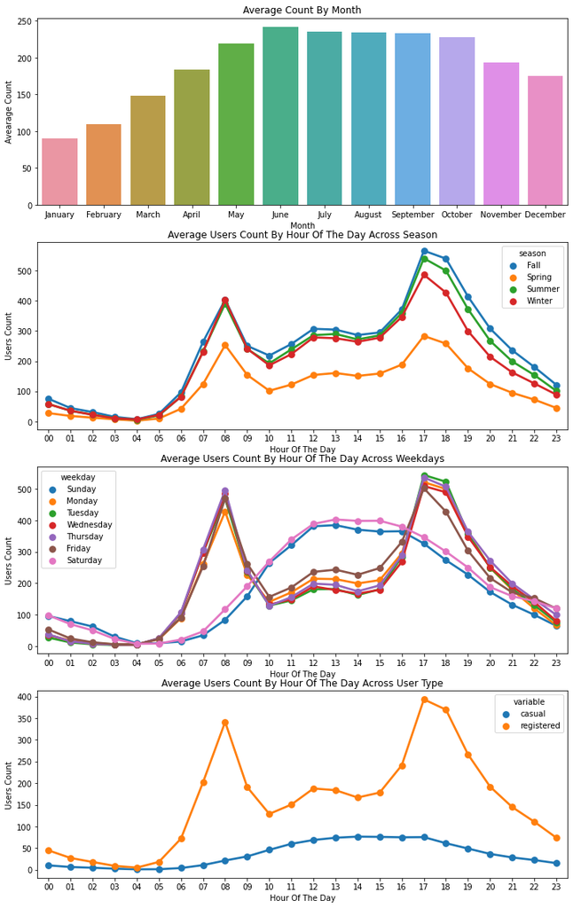

```python
fig,(ax1,ax2,ax3,ax4)= plt.subplots(nrows=4)
fig.set_size_inches(12,20)
sortOrder = ["January","February","March","April","May","June","July","August","September","October","November","December"]
hueOrder = ["Sunday","Monday","Tuesday","Wednesday","Thursday","Friday","Saturday"]

monthAggregated = pd.DataFrame(train_s.groupby("month")["count"].mean()).reset_index()
monthSorted = monthAggregated.sort_values(by="count",ascending=False)
sns.barplot(data=monthSorted,x="month",y="count",ax=ax1,order=sortOrder)
ax1.set(xlabel='Month', ylabel='Avearage Count',title="Average Count By Month")

hourAggregated = pd.DataFrame(train_s.groupby(["hour","season"],sort=True)["count"].mean()).reset_index()
sns.pointplot(x=hourAggregated["hour"], y=hourAggregated["count"],hue=hourAggregated["season"], data=hourAggregated, join=True,ax=ax2)
ax2.set(xlabel='Hour Of The Day', ylabel='Users Count',title="Average Users Count By Hour Of The Day Across Season",label='big')

hourAggregated = pd.DataFrame(train_s.groupby(["hour","weekday"],sort=True)["count"].mean()).reset_index()
sns.pointplot(x=hourAggregated["hour"], y=hourAggregated["count"],hue=hourAggregated["weekday"],hue_order=hueOrder, data=hourAggregated, join=True,ax=ax3)
ax3.set(xlabel='Hour Of The Day', ylabel='Users Count',title="Average Users Count By Hour Of The Day Across Weekdays",label='big')

hourTransformed = pd.melt(train_s[["hour","casual","registered"]], id_vars=['hour'], value_vars=['casual', 'registered'])
hourAggregated = pd.DataFrame(hourTransformed.groupby(["hour","variable"],sort=True)["value"].mean()).reset_index()
sns.pointplot(x=hourAggregated["hour"], y=hourAggregated["value"],hue=hourAggregated["variable"],hue_order=["casual","registered"], data=hourAggregated, join=True,ax=ax4)
ax4.set(xlabel='Hour Of The Day', ylabel='Users Count',title="Average Users Count By Hour Of The Day Across User Type",label='big')
```

```python
train_s
```

|  | season | holiday | workingday | weather | temp | atemp | humidity | windspeed | casual | registered | count | date | hour | weekday | month |
| --- | --- | --- | --- | --- | --- | --- | --- | --- | --- | --- | --- | --- | --- | --- | --- |
| 0 | Spring | 0 | 0 | 1 | 9.84 | 14.395 | 81 | 0.0000 | 3 | 13 | 16 | 2011-01-01 | 00 | Saturday | January |
| 1 | Spring | 0 | 0 | 1 | 9.02 | 13.635 | 80 | 0.0000 | 8 | 32 | 40 | 2011-01-01 | 01 | Saturday | January |
| 2 | Spring | 0 | 0 | 1 | 9.02 | 13.635 | 80 | 0.0000 | 5 | 27 | 32 | 2011-01-01 | 02 | Saturday | January |
| 3 | Spring | 0 | 0 | 1 | 9.84 | 14.395 | 75 | 0.0000 | 3 | 10 | 13 | 2011-01-01 | 03 | Saturday | January |
| 4 | Spring | 0 | 0 | 1 | 9.84 | 14.395 | 75 | 0.0000 | 0 | 1 | 1 | 2011-01-01 | 04 | Saturday | January |
| ... | ... | ... | ... | ... | ... | ... | ... | ... | ... | ... | ... | ... | ... | ... | ... |
| 10881 | Winter | 0 | 1 | 1 | 15.58 | 19.695 | 50 | 26.0027 | 7 | 329 | 336 | 2012-12-19 | 19 | Wednesday | December |
| 10882 | Winter | 0 | 1 | 1 | 14.76 | 17.425 | 57 | 15.0013 | 10 | 231 | 241 | 2012-12-19 | 20 | Wednesday | December |
| 10883 | Winter | 0 | 1 | 1 | 13.94 | 15.910 | 61 | 15.0013 | 4 | 164 | 168 | 2012-12-19 | 21 | Wednesday | December |
| 10884 | Winter | 0 | 1 | 1 | 13.94 | 17.425 | 61 | 6.0032 | 12 | 117 | 129 | 2012-12-19 | 22 | Wednesday | December |
| 10885 | Winter | 0 | 1 | 1 | 13.12 | 16.665 | 66 | 8.9981 | 4 | 84 | 88 | 2012-12-19 | 23 | Wednesday | December |

10886 rows × 15 columns

# Dataset Prepocessing

Now, we have 3 datasets which are slight different, the original data: train_o, modified data: train & train_s. (s means small)

```python
train_s
train_ss=train_s[~train_s['weather'].isin([4])]
```

```python
train_ss
```

|  | season | holiday | workingday | weather | temp | atemp | humidity | windspeed | casual | registered | count | date | hour | weekday | month |
| --- | --- | --- | --- | --- | --- | --- | --- | --- | --- | --- | --- | --- | --- | --- | --- |
| 0 | Spring | 0 | 0 | 1 | 9.84 | 14.395 | 81 | 0.0000 | 3 | 13 | 16 | 2011-01-01 | 00 | Saturday | January |
| 1 | Spring | 0 | 0 | 1 | 9.02 | 13.635 | 80 | 0.0000 | 8 | 32 | 40 | 2011-01-01 | 01 | Saturday | January |
| 2 | Spring | 0 | 0 | 1 | 9.02 | 13.635 | 80 | 0.0000 | 5 | 27 | 32 | 2011-01-01 | 02 | Saturday | January |
| 3 | Spring | 0 | 0 | 1 | 9.84 | 14.395 | 75 | 0.0000 | 3 | 10 | 13 | 2011-01-01 | 03 | Saturday | January |
| 4 | Spring | 0 | 0 | 1 | 9.84 | 14.395 | 75 | 0.0000 | 0 | 1 | 1 | 2011-01-01 | 04 | Saturday | January |
| ... | ... | ... | ... | ... | ... | ... | ... | ... | ... | ... | ... | ... | ... | ... | ... |
| 10881 | Winter | 0 | 1 | 1 | 15.58 | 19.695 | 50 | 26.0027 | 7 | 329 | 336 | 2012-12-19 | 19 | Wednesday | December |
| 10882 | Winter | 0 | 1 | 1 | 14.76 | 17.425 | 57 | 15.0013 | 10 | 231 | 241 | 2012-12-19 | 20 | Wednesday | December |
| 10883 | Winter | 0 | 1 | 1 | 13.94 | 15.910 | 61 | 15.0013 | 4 | 164 | 168 | 2012-12-19 | 21 | Wednesday | December |
| 10884 | Winter | 0 | 1 | 1 | 13.94 | 17.425 | 61 | 6.0032 | 12 | 117 | 129 | 2012-12-19 | 22 | Wednesday | December |
| 10885 | Winter | 0 | 1 | 1 | 13.12 | 16.665 | 66 | 8.9981 | 4 | 84 | 88 | 2012-12-19 | 23 | Wednesday | December |

10885 rows × 15 columns

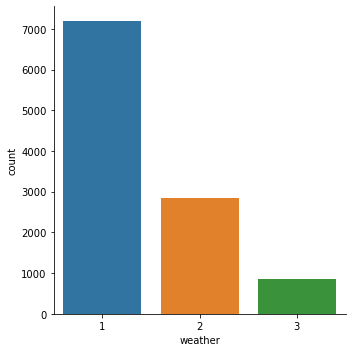

```python
train_ss.weather.value_counts()
sns.factorplot(x='weather',data=train_ss,kind='count',size=5,aspect=1)
```

```python
train_ss=train_ss[~train_ss['holiday'].isin([1])]
```

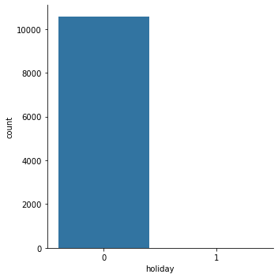

```python
train_ss.holiday.value_counts()
sns.factorplot(x='holiday',data=train_ss,kind='count',size=5,aspect=1)
```

Then we remove the outlier and log target value:

```python
trainss_wo_outlier = train_ss[np.abs(train_ss["count"]-train_ss["count"].mean())<=(3*train_ss["count"].std())]
```

```python
trainss_wo_outlier["count"] = np.log(trainss_wo_outlier["count"])
```

And since the date information is included in weekday and month columns, we can drop it

```python
trainss_wo_outlier.drop(["date"],axis=1,inplace = True)
```

```python
season=pd.get_dummies(trainss_wo_outlier['season'],prefix='season')
trainss_wo_outlier=pd.concat([trainss_wo_outlier,season],axis=1)
trainss_wo_outlier.drop(["season"],axis=1,inplace = True)
```

```python
name_change = {'season_Spring' : 'spring',
               'season_Summer' : 'summer',
               'season_Fall' : 'fall',
               'season_Winter' : 'winter'}
trainss_wo_outlier = trainss_wo_outlier.rename(columns = name_change)
```

```python
trainss_wo_outlier
```

|  | holiday | workingday | weather | temp | atemp | humidity | windspeed | casual | registered | count | hour | weekday | month | fall | spring | summer | winter |
| --- | --- | --- | --- | --- | --- | --- | --- | --- | --- | --- | --- | --- | --- | --- | --- | --- | --- |
| 0 | 0 | 0 | 1 | 9.84 | 14.395 | 81 | 0.0000 | 3 | 13 | 2.772589 | 00 | Saturday | January | 0 | 1 | 0 | 0 |
| 1 | 0 | 0 | 1 | 9.02 | 13.635 | 80 | 0.0000 | 8 | 32 | 3.688879 | 01 | Saturday | January | 0 | 1 | 0 | 0 |
| 2 | 0 | 0 | 1 | 9.02 | 13.635 | 80 | 0.0000 | 5 | 27 | 3.465736 | 02 | Saturday | January | 0 | 1 | 0 | 0 |
| 3 | 0 | 0 | 1 | 9.84 | 14.395 | 75 | 0.0000 | 3 | 10 | 2.564949 | 03 | Saturday | January | 0 | 1 | 0 | 0 |
| 4 | 0 | 0 | 1 | 9.84 | 14.395 | 75 | 0.0000 | 0 | 1 | 0.000000 | 04 | Saturday | January | 0 | 1 | 0 | 0 |
| ... | ... | ... | ... | ... | ... | ... | ... | ... | ... | ... | ... | ... | ... | ... | ... | ... | ... |
| 10881 | 0 | 1 | 1 | 15.58 | 19.695 | 50 | 26.0027 | 7 | 329 | 5.817111 | 19 | Wednesday | December | 0 | 0 | 0 | 1 |
| 10882 | 0 | 1 | 1 | 14.76 | 17.425 | 57 | 15.0013 | 10 | 231 | 5.484797 | 20 | Wednesday | December | 0 | 0 | 0 | 1 |
| 10883 | 0 | 1 | 1 | 13.94 | 15.910 | 61 | 15.0013 | 4 | 164 | 5.123964 | 21 | Wednesday | December | 0 | 0 | 0 | 1 |
| 10884 | 0 | 1 | 1 | 13.94 | 17.425 | 61 | 6.0032 | 12 | 117 | 4.859812 | 22 | Wednesday | December | 0 | 0 | 0 | 1 |
| 10885 | 0 | 1 | 1 | 13.12 | 16.665 | 66 | 8.9981 | 4 | 84 | 4.477337 | 23 | Wednesday | December | 0 | 0 | 0 | 1 |

10427 rows × 17 columns

# Model Fitting

```python
from sklearn.neural_network import MLPRegressor
from sklearn.model_selection import RandomizedSearchCV
```

```python
nn_1 = MLPRegressor(hidden_layer_sizes=(64, ), activation='relu',solver='adam',
                    alpha=0.01,max_iter=200)
```

Here we have a problem. Since the datetime is string type, the fit function does not support.

Using modified data train_o_m

```python
train_o_m = train_o.copy()
train_o_m["hour"] = [t.hour for t in pd.DatetimeIndex(train_o.datetime)]
train_o_m["day"] = [t.dayofweek for t in pd.DatetimeIndex(train_o.datetime)]
train_o_m["month"] = [t.month for t in pd.DatetimeIndex(train_o.datetime)]
train_o_m['year'] = [t.year for t in pd.DatetimeIndex(train_o.datetime)]
train_o_m['year'] = train_o_m['year'].map({2011:0, 2012:1})
train_o_m.drop(["datetime"],axis=1,inplace = True)
```

```python
train_o_m
```

|  | season | holiday | workingday | weather | temp | atemp | humidity | windspeed | casual | registered | count | hour | day | month | year |
| --- | --- | --- | --- | --- | --- | --- | --- | --- | --- | --- | --- | --- | --- | --- | --- |
| 0 | 1 | 0 | 0 | 1 | 9.84 | 14.395 | 81 | 0.0000 | 3 | 13 | 16 | 0 | 5 | 1 | 0 |
| 1 | 1 | 0 | 0 | 1 | 9.02 | 13.635 | 80 | 0.0000 | 8 | 32 | 40 | 1 | 5 | 1 | 0 |
| 2 | 1 | 0 | 0 | 1 | 9.02 | 13.635 | 80 | 0.0000 | 5 | 27 | 32 | 2 | 5 | 1 | 0 |
| 3 | 1 | 0 | 0 | 1 | 9.84 | 14.395 | 75 | 0.0000 | 3 | 10 | 13 | 3 | 5 | 1 | 0 |
| 4 | 1 | 0 | 0 | 1 | 9.84 | 14.395 | 75 | 0.0000 | 0 | 1 | 1 | 4 | 5 | 1 | 0 |
| ... | ... | ... | ... | ... | ... | ... | ... | ... | ... | ... | ... | ... | ... | ... | ... |
| 10881 | 4 | 0 | 1 | 1 | 15.58 | 19.695 | 50 | 26.0027 | 7 | 329 | 336 | 19 | 2 | 12 | 1 |
| 10882 | 4 | 0 | 1 | 1 | 14.76 | 17.425 | 57 | 15.0013 | 10 | 231 | 241 | 20 | 2 | 12 | 1 |
| 10883 | 4 | 0 | 1 | 1 | 13.94 | 15.910 | 61 | 15.0013 | 4 | 164 | 168 | 21 | 2 | 12 | 1 |
| 10884 | 4 | 0 | 1 | 1 | 13.94 | 17.425 | 61 | 6.0032 | 12 | 117 | 129 | 22 | 2 | 12 | 1 |
| 10885 | 4 | 0 | 1 | 1 | 13.12 | 16.665 | 66 | 8.9981 | 4 | 84 | 88 | 23 | 2 | 12 | 1 |

10886 rows × 15 columns

```python
X_train,X_test,y_train,y_test=train_test_split(train_o_m.drop('count',axis=1),train_o_m['count'],test_size=0.1,random_state=81)
y_train = pd.DataFrame(y_train)
y_test = pd.DataFrame(y_test)
```

```python
nn_1.fit(X_train, y_train)

y_pred=nn_1.predict(X_test)
```

```python
y_pred = np.rint(y_pred).astype('int')
```

```python
print(f"Test error: {mean_squared_error(y_test, y_pred):4.3f}")
print(f"Test RMSE: {np.sqrt(mean_squared_error(y_test, y_pred)):4.3f}")

print(f"Test R^2 for the neural network model: {r2_score(y_test, y_pred):4.3f}")
```

```
Test error: 0.033
Test RMSE: 0.182
Test R^2 for the neural network model: 1.000
```

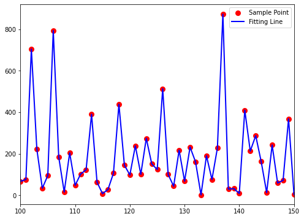

```python
xx=range(0,len(y_test))
plt.figure(figsize=(8,6))
plt.scatter(xx,y_test,color="red",label="Sample Point",linewidth=3)
plt.plot(xx,y_pred,color="blue",label="Fitting Line",linewidth=2)
plt.xlim(100, 150)
plt.legend()
plt.show()
```

## GridSearchCV for tuning

```python
nn_1.get_params()
```

```
{'activation': 'relu',
 'alpha': 0.01,
 'batch_size': 'auto',
 'beta_1': 0.9,
 'beta_2': 0.999,
 'early_stopping': False,
 'epsilon': 1e-08,
 'hidden_layer_sizes': (64,),
 'learning_rate': 'constant',
 'learning_rate_init': 0.001,
 'max_fun': 15000,
 'max_iter': 200,
 'momentum': 0.9,
 'n_iter_no_change': 10,
 'nesterovs_momentum': True,
 'power_t': 0.5,
 'random_state': None,
 'shuffle': True,
 'solver': 'adam',
 'tol': 0.0001,
 'validation_fraction': 0.1,
 'verbose': False,
 'warm_start': False}
```

We just changed batch_size, hidden_layer_sizes and penalty coeff $\alpha$  
Since running time might be long in neural network fitting, we use RandomizedSearchCV.

```python
nn = MLPRegressor(activation='relu',solver='adam', max_iter=200)
param_grid = {'alpha': [0.005, 0.01, 0.02],
              'batch_size': ['auto', 500, 1000],
              'hidden_layer_sizes': [(64, ), (64, 32, 64)]}
nn_2 = RandomizedSearchCV(nn, param_grid, return_train_score=True, scoring='r2', cv=5)
nn_2.fit(X_train, y_train)

y_pred=nn_2.predict(X_test)
```

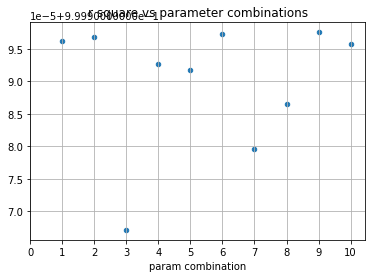

```python
plt.scatter(range(1, 11), nn_2.cv_results_['mean_test_score'], s=20)
plt.grid(True)
plt.title("r square vs parameter combinations")
plt.xlabel("param combination")
plt.xticks(np.arange(0, 11, 1))
plt.show()
```

```python
nn_2.cv_results_['params']
```

```
[{'hidden_layer_sizes': (64, 32, 64), 'batch_size': 'auto', 'alpha': 0.005},
 {'hidden_layer_sizes': (64, 32, 64), 'batch_size': 500, 'alpha': 0.01},
 {'hidden_layer_sizes': (64,), 'batch_size': 1000, 'alpha': 0.01},
 {'hidden_layer_sizes': (64,), 'batch_size': 500, 'alpha': 0.02},
 {'hidden_layer_sizes': (64, 32, 64), 'batch_size': 1000, 'alpha': 0.02},
 {'hidden_layer_sizes': (64, 32, 64), 'batch_size': 500, 'alpha': 0.005},
 {'hidden_layer_sizes': (64,), 'batch_size': 1000, 'alpha': 0.005},
 {'hidden_layer_sizes': (64,), 'batch_size': 500, 'alpha': 0.01},
 {'hidden_layer_sizes': (64, 32, 64), 'batch_size': 500, 'alpha': 0.02},
 {'hidden_layer_sizes': (64, 32, 64), 'batch_size': 'auto', 'alpha': 0.01}]
```

```python
print("Results after change in batch_size, hidden_layer_sizes and penalty coeff $\alpha$  ")
print(f"Test error: {mean_squared_error(y_test, y_pred):4.3f}")
print(f"Test RMSE: {np.sqrt(mean_squared_error(y_test, y_pred)):4.3f}")

print(f"Test R^2 for the neural network model: {r2_score(y_test, y_pred):4.3f}")
```

```
Results after change in batch_size, hidden_layer_sizes and penalty coeff $lpha$
Test error: 0.064
Test RMSE: 0.252
Test R^2 for the neural network model: 1.000
```

### The best score is:

```python
nn_2.best_score_
```

```
0.9999975683318277
```

### The best parameter combine is:

```python
nn_2.best_params_
```

```
{'hidden_layer_sizes': (64, 32, 64), 'batch_size': 500, 'alpha': 0.02}
```

In addition, we also use this predictor to predict test data, and get the result:

```
Test error: 0.060
Test R^2 for the neural network model: 1.000
```

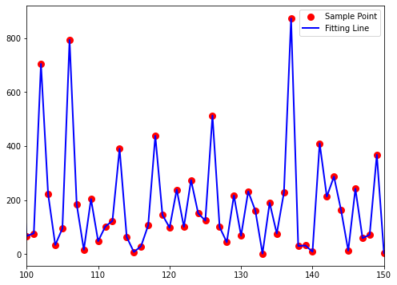

```python
y_pred = np.rint(y_pred).astype('int')
print(f"Test error: {mean_squared_error(y_test, y_pred):4.3f}")
print(f"Test R^2 for the neural network model: {r2_score(y_test, y_pred):4.3f}")
xx=range(0,len(y_test))
plt.figure(figsize=(8,6))
plt.scatter(xx,y_test,color="red",label="Sample Point",linewidth=3)
plt.plot(xx,y_pred,color="blue",label="Fitting Line",linewidth=2)
plt.xlim(100, 150)
plt.legend()
plt.show()
```

This model is overfitting.

## A big mistake

We found the r square is really close to 1, and it is impossible. We figured that it is caused by retaining the casual and registered features, and the target feature is sum of them. So we droped these columns.

```python
train_o_m.drop(["casual", "registered"],axis=1,inplace = True)
```

```python
train_o_m
```

|  | season | holiday | workingday | weather | temp | atemp | humidity | windspeed | count | hour | day | month | year |
| --- | --- | --- | --- | --- | --- | --- | --- | --- | --- | --- | --- | --- | --- |
| 0 | 1 | 0 | 0 | 1 | 9.84 | 14.395 | 81 | 0.0000 | 16 | 0 | 5 | 1 | 0 |
| 1 | 1 | 0 | 0 | 1 | 9.02 | 13.635 | 80 | 0.0000 | 40 | 1 | 5 | 1 | 0 |
| 2 | 1 | 0 | 0 | 1 | 9.02 | 13.635 | 80 | 0.0000 | 32 | 2 | 5 | 1 | 0 |
| 3 | 1 | 0 | 0 | 1 | 9.84 | 14.395 | 75 | 0.0000 | 13 | 3 | 5 | 1 | 0 |
| 4 | 1 | 0 | 0 | 1 | 9.84 | 14.395 | 75 | 0.0000 | 1 | 4 | 5 | 1 | 0 |
| ... | ... | ... | ... | ... | ... | ... | ... | ... | ... | ... | ... | ... | ... |
| 10881 | 4 | 0 | 1 | 1 | 15.58 | 19.695 | 50 | 26.0027 | 336 | 19 | 2 | 12 | 1 |
| 10882 | 4 | 0 | 1 | 1 | 14.76 | 17.425 | 57 | 15.0013 | 241 | 20 | 2 | 12 | 1 |
| 10883 | 4 | 0 | 1 | 1 | 13.94 | 15.910 | 61 | 15.0013 | 168 | 21 | 2 | 12 | 1 |
| 10884 | 4 | 0 | 1 | 1 | 13.94 | 17.425 | 61 | 6.0032 | 129 | 22 | 2 | 12 | 1 |
| 10885 | 4 | 0 | 1 | 1 | 13.12 | 16.665 | 66 | 8.9981 | 88 | 23 | 2 | 12 | 1 |

10886 rows × 13 columns

```python
nn_1 = MLPRegressor(hidden_layer_sizes=(64, ), activation='relu',solver='adam',
                    alpha=0.01,max_iter=200)
X_train,X_test,y_train,y_test=train_test_split(train_o_m.drop('count',axis=1),train_o_m['count'],test_size=0.1,random_state=81)
y_train = pd.DataFrame(y_train)
y_test = pd.DataFrame(y_test)
nn_1.fit(X_train, y_train)

y_pred=nn_1.predict(X_test)
y_pred = np.rint(y_pred).astype('int')
```

```python
print(f"Test error: {mean_squared_error(y_test, y_pred):4.3f}")
print(f"RMSE: {np.sqrt(mean_squared_error(y_test, y_pred)):4.3f}")
print(f"Test R^2 for the neural network model: {r2_score(y_test, y_pred):4.3f}")
```

```
Test error: 15602.406
RMSE: 124.910
Test R^2 for the neural network model: 0.541
```

The r2 is quite low. And the prediction is not accurate as well.

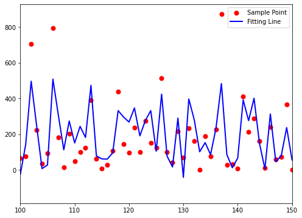

```python
xx=range(0,len(y_test))
plt.figure(figsize=(8,6))
plt.scatter(xx,y_test,color="red",label="Sample Point",linewidth=2)
plt.plot(xx,y_pred,color="blue",label="Fitting Line",linewidth=2)
plt.xlim(100, 150)
plt.legend()
plt.show()
```

```python
nn = MLPRegressor(activation='relu',solver='adam', max_iter=200)
param_grid = {'alpha': [0.005, 0.01, 0.02],
              'batch_size': ['auto', 500, 1000],
              'hidden_layer_sizes': [(64, ), (64, 32, 64)]}
nn_2 = RandomizedSearchCV(nn, param_grid, return_train_score=True, scoring='r2', cv=5)
nn_2.fit(X_train, y_train)

y_pred=nn_2.predict(X_test)
```

```python
print(f"Test error: {mean_squared_error(y_test, y_pred):4.3f}")
print(f"RMSE: {np.sqrt(mean_squared_error(y_test, y_pred)):4.3f}")
print(f"Test R^2 for the neural network model: {r2_score(y_test, y_pred):4.3f}")
```

```
Test error: 10830.596
RMSE: 104.070
Test R^2 for the neural network model: 0.681
```

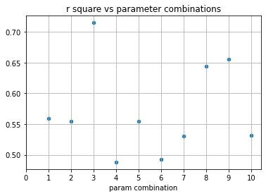

```python
plt.scatter(range(1, 11), nn_2.cv_results_['mean_test_score'], s=20)
plt.grid(True)
plt.title("r square vs parameter combinations")
plt.xlabel("param combination")
plt.xticks(np.arange(0, 11, 1))
plt.show()
```

We can conclude that neural network model with the third param combination has the highest r square, which is the best.

### The best score is:

```python
nn_2.best_score_
```

```
0.7147778196999444
```

### The best parameter combine is:

```python
nn_2.best_params_
```

```
{'hidden_layer_sizes': (64, 32, 64), 'batch_size': 500, 'alpha': 0.01}
```

### Let us see what's happend on the test data:

```
Test error: 10831.032
Test error: 104.072
Test R^2 for the neural network model: 0.681
```

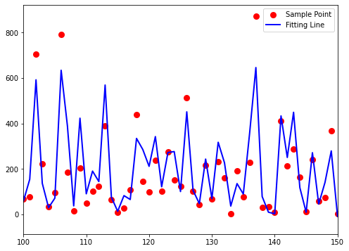

```python
y_pred = np.rint(y_pred).astype('int')
print(f"Test error: {mean_squared_error(y_test, y_pred):4.3f}")
print(f"Test error: {np.sqrt(mean_squared_error(y_test, y_pred)):4.3f}")

print(f"Test R^2 for the neural network model: {r2_score(y_test, y_pred):4.3f}")
xx=range(0,len(y_test))
plt.figure(figsize=(8,6))
plt.scatter(xx,y_test,color="red",label="Sample Point",linewidth=3)
plt.plot(xx,y_pred,color="blue",label="Fitting Line",linewidth=2)
plt.xlim(100, 150)
plt.legend()
plt.show()
```

*nn after spliting the data*

```python
X_train,X_test,y_train,y_test=train_test_split(trainm_wo_outlier.drop('count',axis=1),trainm_wo_outlier['count'],test_size=0.1,random_state=81)
y_train = pd.DataFrame(y_train)
y_test = pd.DataFrame(y_test)

nn = MLPRegressor(activation='relu',solver='adam', max_iter=200)
param_grid = {'alpha': [0.005, 0.01, 0.02],
              'batch_size': ['auto', 500, 1000],
              'hidden_layer_sizes': [(64, ), (64, 32, 64)]}
nn_3 = RandomizedSearchCV(nn, param_grid, return_train_score=True, scoring='r2', cv=5)
nn_3.fit(X_train, y_train)
y_pred=nn_3.predict(X_test)
```

```python
print(f"Test error: {mean_squared_error(y_test, y_pred):4.3f}")
print(f"RMSE: {np.sqrt(mean_squared_error(y_test, y_pred)):4.3f}")
print(f"Test R^2 for the neural network model: {r2_score(y_test, y_pred):4.3f}")
```

```
Test error: 0.212
RMSE: 0.461
Test R^2 for the neural network model: 0.904
```

```
Test error: 0.296
Test error: 0.544
Test R^2 for the neural network model: 0.866
```

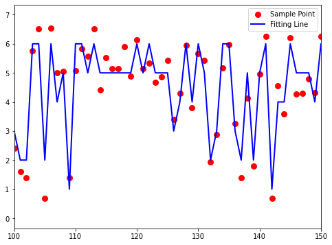

```python
y_pred = np.rint(y_pred).astype('int')
print(f"Test error: {mean_squared_error(y_test, y_pred):4.3f}")
print(f"Test error: {np.sqrt(mean_squared_error(y_test, y_pred)):4.3f}")

print(f"Test R^2 for the neural network model: {r2_score(y_test, y_pred):4.3f}")
xx=range(0,len(y_test))
plt.figure(figsize=(8,6))
plt.scatter(xx,y_test,color="red",label="Sample Point",linewidth=3)
plt.plot(xx,y_pred,color="blue",label="Fitting Line",linewidth=2)
plt.xlim(100, 150)
plt.legend()
plt.show()
```

```python
nn_4 = MLPRegressor(hidden_layer_sizes=(64, ), activation='relu',solver='adam',
                    alpha=0.01,max_iter=200)
nn_4.fit(X_train, y_train)
y_pred=nn_4.predict(X_test)
```

```python
#nn_4.best_params_
```

```python
#nn_4.best_score_
```

```python
print(f"Test error: {mean_squared_error(y_test, y_pred):4.3f}")
print(f"RMSE: {np.sqrt(mean_squared_error(y_test, y_pred)):4.3f}")
print(f"Test R^2 for the neural network model: {r2_score(y_test, y_pred):4.3f}")
```

```
Test error: 0.338
RMSE: 0.582
Test R^2 for the neural network model: 0.847
```

```
Test error: 0.412
Test error: 0.642
Test R^2 for the neural network model: 0.814
```

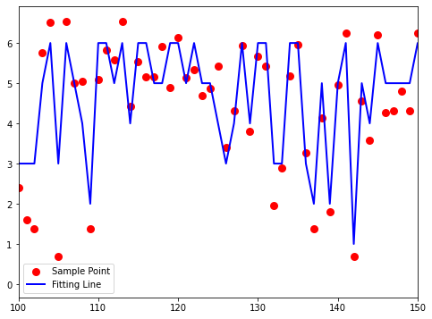

```python
y_pred = np.rint(y_pred).astype('int')
print(f"Test error: {mean_squared_error(y_test, y_pred):4.3f}")
print(f"Test error: {np.sqrt(mean_squared_error(y_test, y_pred)):4.3f}")

print(f"Test R^2 for the neural network model: {r2_score(y_test, y_pred):4.3f}")
xx=range(0,len(y_test))
plt.figure(figsize=(8,6))
plt.scatter(xx,y_test,color="red",label="Sample Point",linewidth=3)
plt.plot(xx,y_pred,color="blue",label="Fitting Line",linewidth=2)
plt.xlim(100, 150)
plt.legend()
plt.show()
```

We getting better than use original neural network model, but performance is still worse than randomforest and bagging regression.

# Random Forest -

```python
X_train,X_test,y_train,y_test=train_test_split(train_o_m.drop('count',axis=1),train_o_m['count'],test_size=0.1,random_state=81)
y_train = pd.DataFrame(y_train)
y_test = pd.DataFrame(y_test)
```

using randomforest, adaboost and bagging

```python
models=[RandomForestRegressor(),AdaBoostRegressor(),BaggingRegressor()]
model_names=['RandomForestRegressor','AdaBoostRegressor','BaggingRegressor']
mse=[]
rmse=[]
r2=[]
a={}
for model in range (len(models)):
    clf=models[model]
    clf.fit(X_train,y_train)
    y_pred=clf.predict(X_test)
    mse.append(mean_squared_error(y_pred,y_test))
    rmse.append(np.sqrt(mean_squared_error(y_pred,y_test)))
    r2.append(r2_score(y_pred,y_test))
a={'Modelling Algo':model_names,'MSE':mse, 'RMSE':rmse, 'R2':r2}
```

```python
result_frame=pd.DataFrame(a)
result_frame
```

|  | Modelling Algo | MSE | RMSE | R2 |
| --- | --- | --- | --- | --- |
| 0 | RandomForestRegressor | 1560.146677 | 39.498692 | 0.951614 |
| 1 | AdaBoostRegressor | 11034.538591 | 105.045412 | 0.498605 |
| 2 | BaggingRegressor | 1750.625721 | 41.840479 | 0.946010 |

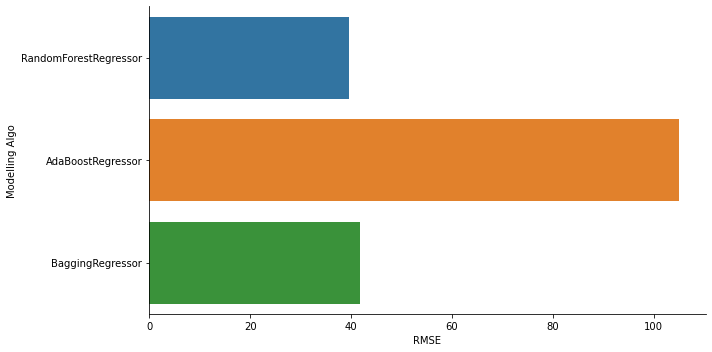

```python
sns.factorplot(y='Modelling Algo',x='RMSE',data=result_frame,kind='bar',size=5,aspect=2)
```

Random forest on original data :train_o_m

```python
train_o_m.dtypes
```

```
season          int64
holiday         int64
workingday      int64
weather         int64
temp          float64
atemp         float64
humidity        int64
windspeed     float64
count           int64
hour            int64
day             int64
month           int64
year            int64
dtype: object
```

```python
no_of_test=[500,1000]
params_dict={'n_estimators':no_of_test,'n_jobs':[-1],'max_depth':[8,10]}
clf_rf=GridSearchCV(estimator=RandomForestRegressor(),param_grid=params_dict,scoring='r2',cv=5)
clf_rf.fit(X_train,y_train)
pred=clf_rf.predict(X_test)
print(f"Test MSE for random forest: {mean_squared_error(y_test, pred):4.3f}")
print(f"Test RMSE for random forest: {np.sqrt(mean_squared_error(y_test, pred)):4.3f}")
print(f"Test R^2 for the random forest model: {r2_score(y_test, pred):4.3f}")
```

```
Test MSE for random forest: 2237.394
Test RMSE for random forest: 47.301
Test R^2 for the random forest model: 0.934
```

```python
clf_rf.best_params_
```

```
{'max_depth': 10, 'n_estimators': 1000, 'n_jobs': -1}
```

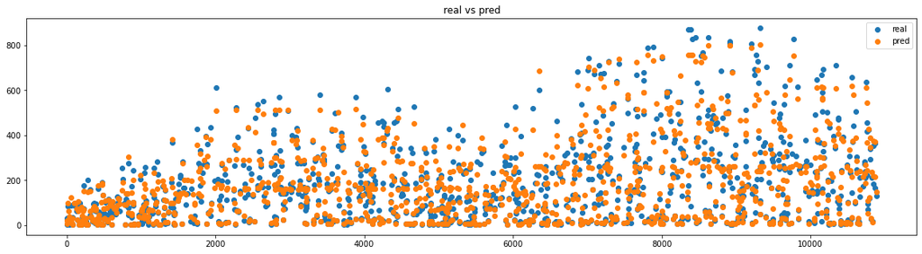

```python
plt.figure(figsize=(20, 5))
plt.scatter(y_test.index, y_test, label="real")
plt.scatter(y_test.index, pred, label="pred")
plt.title('real vs pred')
plt.legend()
plt.show()
```

Our predicted data fits well with the real data for RF

## Model fitting for another version of dataset

Random Forest with new table:

```python
X_train,X_test,y_train,y_test=train_test_split(trainm_wo_outlier.drop('count',axis=1),trainm_wo_outlier['count'],test_size=0.1,random_state=81)
y_train = pd.DataFrame(y_train)
y_test = pd.DataFrame(y_test)
```

```python
no_of_test=[500,1000]
params_dict={'n_estimators':no_of_test,'n_jobs':[-1],'max_depth':[8,10]}
clf_rf2=GridSearchCV(estimator=RandomForestRegressor(),param_grid=params_dict,scoring='r2',cv=5)
clf_rf2.fit(X_train,y_train)
pred_rf2=clf_rf2.predict(X_test)
```

```python
print(f"Test MSE for random forest: {mean_squared_error(pred_rf2, y_test):4.3f}")
print(f"Test RMSE for random forest: {np.sqrt(mean_squared_error(pred_rf2, y_test)):4.3f}")
print(f"Test R^2 for the random forest model: {r2_score(pred_rf2, y_test):4.3f}")
```

```
Test MSE for random forest: 0.185
Test RMSE for random forest: 0.430
Test R^2 for the random forest model: 0.907
```

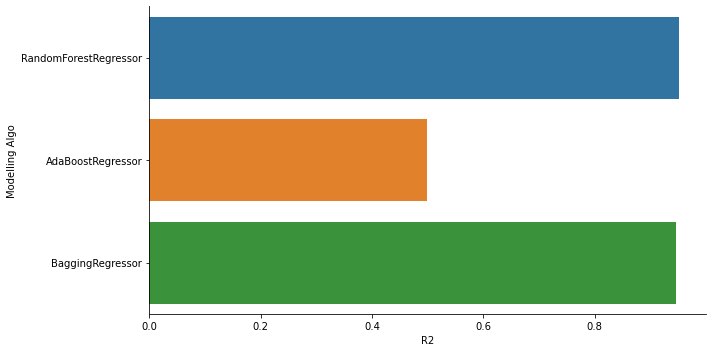

```python
sns.factorplot(y='Modelling Algo',x='R2',data=result_frame,kind='bar',size=5,aspect=2)
```

```python
clf_rf.best_params_
```

```
{'max_depth': 10, 'n_estimators': 1000, 'n_jobs': -1}
```

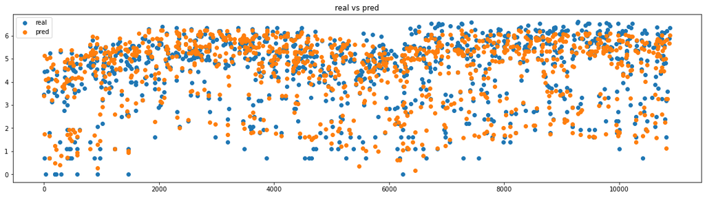

```python
plt.figure(figsize=(20, 5))
plt.scatter(y_test.index, y_test, label="real")
plt.scatter(y_test.index, pred_rf2, label="pred")
plt.title('real vs pred')
plt.legend()
plt.show()
```